# KQF cleaning report

Fall 2022

Evan Krause

2022-12-11

# 1 **Project pages**

[KQF project github](https://github.com/mrmarbles42/KQF-project)

# 2 **Semester Objective**

- Collect and prepare data files into a cohesive data set
- Check for consistency, accuracy, and uniformity
- Remove redundant or inapplicable information

# 3 **Input data descriptions**

- **Structure diagram of input data**

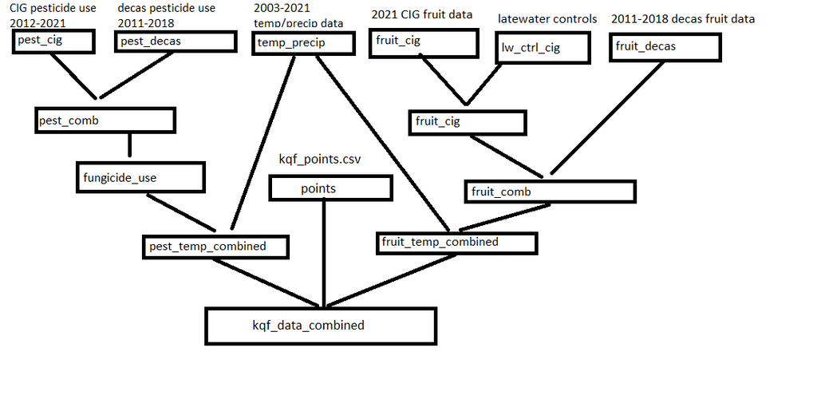

## 3.1 Decas

### 3.1.1 Decas fruit data

```r
#data file import
fruit_12 <- fread(here("data/base_files","grower_yield_rpt_2012.csv"))
fruit_13 <- fread(here("data/base_files","grower_yield_rpt_2013.csv"))
fruit_14 <- fread(here("data/base_files","grower_yield_rpt_2014.csv"))
fruit_15 <- fread(here("data/base_files","grower_yield_rpt_2015.csv"))
fruit_16 <- fread(here("data/base_files","grower_yield_rpt_2016.csv"))
fruit_17 <- fread(here("data/base_files","grower_yield_rpt_2017.csv"))
fruit_18 <- fread(here("data/base_files","grower_yield_rpt_2018.csv"))

#combine as list
fruit_decas <- list(fruit_13,
                    fruit_14,
                    fruit_15,
                    fruit_16,
                    fruit_17,
                    fruit_18)

#remove duplicate column
fruit_decas$GTL <- NULL

#bind list
fruit_decas <-
  rbindlist(fruit_decas,
        fill = T)

#select columns
fruit_decas <- fruit_decas %>%
  select(grower_id,
         deliver_date,
         Bog,
         Rot,
         Debris,
         Color,
         Variety)
#rename columns
colnames(fruit_decas) <- c("grower",
                                "date",
                                "bog",
                                "rot_pct",
                                "debris",
                                "color",
                                "variety")
```

### 3.1.2 Decas pesticide data

- File name: Pest_use_decas.csv
- Dimensions: 62,915 x 11
- Date range: March – October (2011 – 2018)
- Description: Pesticide application data from Decas growers
- Imported as: **“pest_decas”**

```r
#data file import
pest_decas <- fread(here("data/base_files","pest_use_decas.csv"))
```

## 3.2 CIG

### 3.2.1 CIG fruit data

- File name: cig_yield_bloom.csv
- Dimensions: 95 x 10
- Date range: 2021
- Description: Harvest quality data from L. Uppala
- Imported as: **“fruit_cig”**

```r
#data file import
fruit_cig <- fread(here("data/base_files", "cig_yield_bloom.csv"))
```

### 3.2.2 CIG latewater control data

- File name: 2021_cig_latewater_controls.csv
- Dimensions: 20 x 8
- Date range: 2021
- Description: Harvest quality data (latewater experimental controls) from L. Uppala
- Imported as: **“lw_ctrl_cig”**

```r
#data file import
lw_ctrl_cig <- fread(here("data", "2021_cig_latewater_controls.csv"))
```

### 3.2.3 CIG pesticide use data

- File name: pest_use_cig.csv
- Dimensions: 350 x 9
- Date range: May – August (2012 — 2021)
- Description: Pesticide application data from CIG growers
- Imported as: **“pest_cig”**

```r
#data file import
pest_cig <- fread(here("data/base_files", "pest_use_cig.csv"))
```

## 3.3 Temperature and precipitation

- File name: kqf_temp_precip.csv
- Dimensions: 240 x 5
- Date range: January 2003 - December 2021
- Description: Average temperature (F) and total precipitation (in) by month
- Imported as: **“temp_precip”**

```r
#data file import
temp_precip <- fread(here("data/base_files", "kqf_temp_precip.csv"))
```

## 3.4 KQF point values

```r
points <- fread(here("data/base_files", "kqf_points.csv"))
```

# 4 **Data processing**

## 4.1 Decas

### 4.1.1 Decas fruit quality

```r
##date manipulation
fruit_decas$date <- parse_date_time(fruit_decas$date, "mdy")

##collapsed varieties vector
other_varieties = c("OE","ORST","OH",
                    "OM","GR","OB",
                    "SN","MC","SK",
                    "ORHO","OS","MX",
                    "GD","PD")

fruit_decas <- fruit_decas %>%
  ##exclude rows w/ NA values in rot
  filter(is.na(rot_pct) == F) %>%
  ##create log_rot / year / month columns and collapse varieties by frequency
  mutate(
    log_rot = log10(rot_pct + 1) ,
    variety = fct_collapse(variety, other = other_varieties),
    year = lubridate::year(date),
    month = lubridate::month(date),
  ##create data_source column
    data_source = as.factor("decas")
  ) %>%
  ##relocate date column to [,1]
  relocate(date)
```

### 4.1.2 Decas pesticide use

- Date column changed from character class to POSIXct (datetime class)
- Selected for columns “date”, “grower”, “bog”, “treatment”, “active_ingredient”
- Date column moved to first position
- Data_source column created and given value “decas”

```r
##application_date (char to POSIXct)
pest_decas$date <- parse_date_time(pest_decas$application_date, "mdy")

pest_decas <- pest_decas %>%
  #remove old application_date and extraneous columns
  select(date,
         grower,
         bog,
         treatment,
         active_ingredient) %>%
  #relocate new date column
  relocate(date) %>%
  #create data_source column
  mutate(data_source = "decas")
```

## 4.2 CIG

### 4.2.1 CIG fruit quality

#### 4.2.1.1 fruit_cig

- Rows with NA value in rot percentage column excluded
- Log transform of rot percentage column created
- variety column created and given value “ST”
- Year and month columns created
- Data_source column created and given value “cig”
- Column names reformatted

```r
fruit_cig <- fruit_cig %>%
  ##exclude rows w/ NA values in rot
  filter(is.na(rot_pct) == F) %>%
  ##create log_rot, variety, year, and data source columns
  mutate(
    log_rot = log10(rot_pct + 1),
    variety = as_factor("ST"),
    year = 2021,
    month = 10,
    data_source = "cig"
  ) %>%
  rename("yield_acre_barrel" = "yield_per_ac_barrel",
         "yield_ha_barrel" = "yield_p_ha_barrel",
         "yield_ac_kg" = "yield_p_ac_kg",
         "yield_ac_lb" = "yield_p_ac_lb",
         "site" = "Site",
         "rep" = "Rep")
```

#### 4.2.1.2 Lw_ctrl_cig

- Column names reformatted
- Log transform of rot percentage column created
- Converted yield columns created
- Data_source column created and given value “cig_lw”
- Site column created and given value 0
- variety column created and given value “ST”

```r
lw_ctrl_cig <- lw_ctrl_cig %>%
#rename cols based on cig_fruit names
  rename("yield_acre_barrel" = "yield per acre",
         "rot_pct" = "pct_rot",
         "wt_p_berry" = "wt_per_berry") %>%
  #create yield, data_source, site, variety, kqf, and log(rot) columns
  mutate(yield_ha_barrel = yield_acre_barrel * 2.471,
         yield_ac_kg = yield_acre_barrel * 45.35929257,
         yield_ac_lb = yield_ac_kg * 2.20463,
         data_source = "cig_lw",
         site = 0,
         log_rot = log10(rot_pct + 1),
         variety = "ST")
```

### 4.2.2 CIG pesticide use

- Date column created as POSIXct class
- Selected for columns “date”, “grower”, “bog”, “treatment”, “active_ingredient”
- Date column moved to first position
- Data_source column created and given value “cig”

```r
pest_cig <- pest_cig %>%
  ##application_date (char to POSIXct)
  mutate(date = parse_date_time(application_date, orders = "ymd")) %>%
  #remove old application_date and select non-extraneous columns
  select(date,
         grower,
         Bog,
         treatment,
         active_ingredient) %>%
  #relocate new date column
  relocate(date) %>%
  #create data_source col
  mutate(data_source = 'cig') %>%
  rename("bog" = "Bog")
```

## 4.3 Temperature and precipitation

- Year and month columns created

```r
temp_precip <- temp_precip %>%
  mutate(month = lubridate::month(date),
         year = lubridate::year(date))
```

## 4.4 KQF points

- date_year column renamed to year

```r
points <- points %>%
  mutate(year = as.numeric(date_year))
```

## 4.5 Combined data

### 4.5.1 Combined pesticide data

- Pest_cig and pest_decas tables merged on specified columns into **“pest_comb”** table
- Year and month columns created-
- Duplicated ingredients from active_ingredient column renamed and collapsed into single factors
- Active_ingredient column filtered for selected fungicides and renamed “fungicide_use”
- Temp_precip table and fungicide_use tables merged by year and month columns into table “pest_temp_combined”

```r
##define join columns
comb_pest_cols <- c("date",
                    "treatment",
                    "active_ingredient",
                    "grower",
                    "bog",
                    "data_source")

##full join on defined columns
pest_comb <- pest_decas %>%
  full_join(pest_cig, by = comb_pest_cols, suffix = c("_decas", "_cig")) %>%
  mutate(month = lubridate::month(date),
         year = lubridate::year(date))

#redefine and collapse repeated fungicides
pest_comb$active_ingredient <-
  str_replace_all(
    pest_comb$active_ingredient,
    c(
      "Manganese ethylenebisdithiocarbamate" = "EBDC",
      "Mancozeb" = "EBDC",
      "EDBC" = "EBDC",
      "Polyoxin D Zinc Salt" = "Polyoxin D",
      "Polyoxin D zinc salt" = "Polyoxin D"
    )
  )

#define alternative fungicides
other_ingredients <- c("Cuprous Oxide",
                       "Fosetyl-Al",
                       "Polyoxin D")

fungicide_use <- pest_comb %>%
  #filter out non-fungicide treatments
  filter(
    active_ingredient %in% c(
      "Copper Hydroxide",
      "Cuprous Oxide",
      "Polyoxin D",
      "Chlorothalonil",
      "Azoxystrobin",
      "Fenbuconazole",
      "Fosetyl-Al",
      "EBDC",
      "Ferbam"
    )
  ) %>%
  #collapse fungicides w/ <50 instances and rm original column
  mutate(ingredient = fct_collapse(active_ingredient,
                                   other = other_ingredients)) %>%
  select(-active_ingredient)

pest_temp_combined <- fungicide_use %>%
  full_join(temp_precip, by = c("year", "month"), suffix = c("_fungi", "_temps")) %>%
  select(-date_temps) %>%
  rename("date" = "date_fungi")
```

### 4.5.2 Combined fruit quality data

- Fruit_cig and fruit_decas tables bound by rows into table **“fruit_comb”**
- Temp_precip table and fruit_comb tables merged by year and month columns into table “fruit_temp_combined”

```r
fruit_comb <- bind_rows(fruit_cig, fruit_decas)

fruit_temp_combined <- fruit_comb %>%
  full_join(temp_precip, by = c("year", "month")) %>%
  select(-date.y) %>%
  rename("date" = "date.x")
```

### 4.5.3 Full dataset

- Fruit_temp_combined and pest_temp_combined tables merged on specified columns into **“kqf_data_combined”** table
- “Variety”, “site”, “rep”, “data_source”, “treatment”, and “ingredient” columns coerced to factors
- Kqf_data_combined and points tables merged on year column into “kqf_data_combined”

```r
##define joining columns for combined data
comb_cols <- c("data_source", "date", "month", "year", "avg_temp_f", "tot_precip", "grower", "bog")

#Join all columns on joining vec
kqf_data_combined <- fruit_temp_combined %>%
  full_join(pest_temp_combined,
            by = comb_cols,
            suffix = c("_fruit", "_pest"))

##factor coercion
kqf_data_combined$variety <- as_factor(kqf_data_combined$variety)
kqf_data_combined$site <- as_factor(kqf_data_combined$site)
kqf_data_combined$rep <- as_factor(kqf_data_combined$rep)
kqf_data_combined$data_source <- as_factor(kqf_data_combined$data_source)
kqf_data_combined$treatment <- as_factor(kqf_data_combined$treatment)
kqf_data_combined$ingredient <- as_factor(kqf_data_combined$ingredient)

#join kqf points column
kqf_data_combined <- kqf_data_combined %>%
  full_join(points, by = c("year")) %>%
  select(-date_year)
```

# 5 **Data exploration**

## 5.1 Whole dataset

**Combined dataset classes**

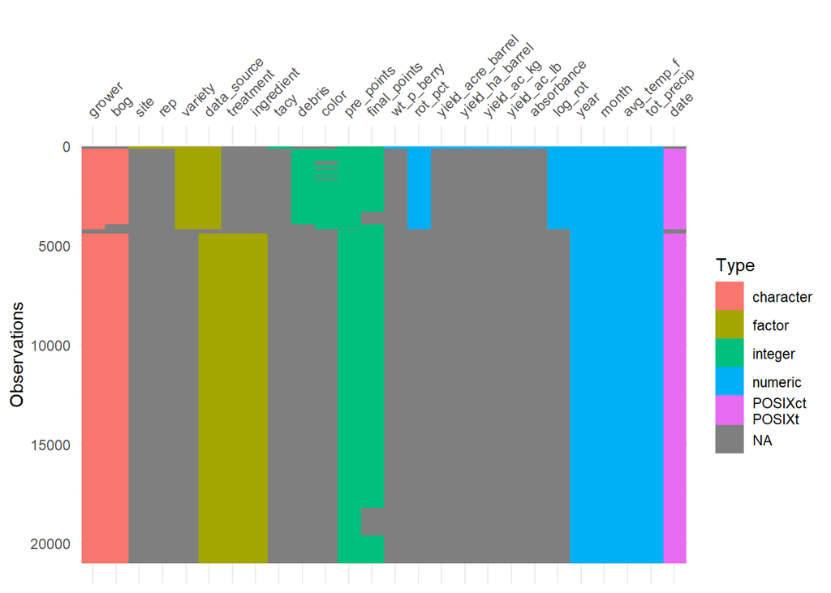

```r
vis_dat(kqf_data_combined)
```

**Combined dataset missing data structure**

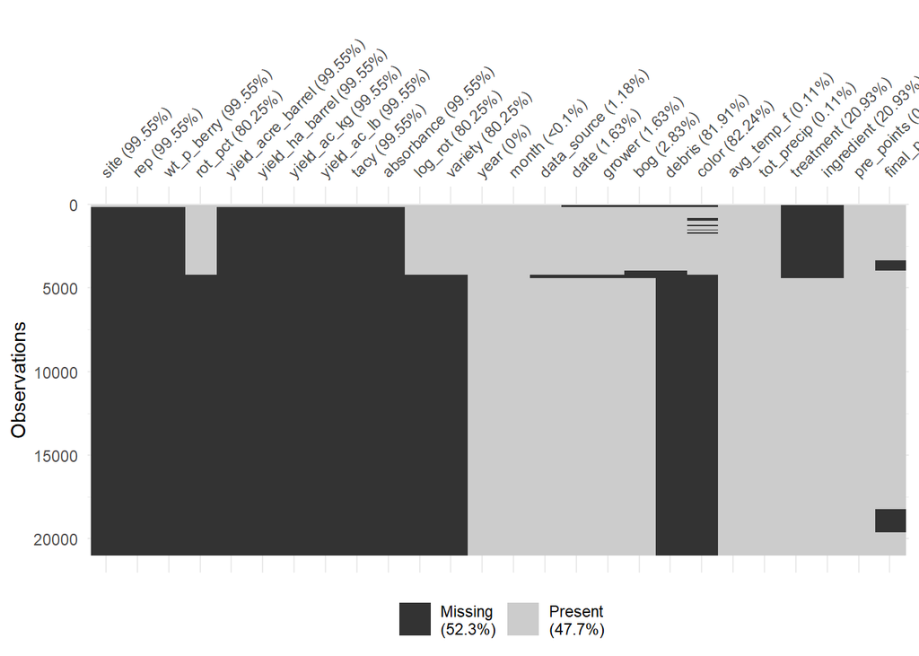

```r
vis_miss(kqf_data_combined)
```

**Summary statistics**

```r
kqf_data_combined %>%
  summary(.)
```

```
##       site         rep          wt_p_berry       rot_pct
##  1      :    5   1   :   19   Min.   :0.931   Min.   : 0.000
##  2      :    5   2   :   19   1st Qu.:1.596   1st Qu.: 1.480
##  3      :    5   3   :   19   Median :1.758   Median : 2.645
##  4      :    5   4   :   19   Mean   :1.761   Mean   : 4.016
##  5      :    5   5   :   19   3rd Qu.:1.920   3rd Qu.: 4.598
##  (Other):   70   NA's:20897   Max.   :2.250   Max.   :63.310
##  NA's   :20897                NA's   :20897   NA's   :16846
##  yield_acre_barrel yield_ha_barrel  yield_ac_kg     yield_ac_lb
##  Min.   : 58.96    Min.   : 6606   Min.   : 2675   Min.   : 5896
##  1st Qu.:166.76    1st Qu.:18683   1st Qu.: 7564   1st Qu.:16676
##  Median :199.09    Median :22305   Median : 9030   Median :19909
##  Mean   :208.65    Mean   :23376   Mean   : 9464   Mean   :20865
##  3rd Qu.:251.46    3rd Qu.:28173   3rd Qu.:11406   3rd Qu.:25146
##  Max.   :387.73    Max.   :43440   Max.   :17587   Max.   :38772
##  NA's   :20897     NA's   :20897   NA's   :20897   NA's   :20897
##       tacy         absorbance       log_rot       variety           year
##  Min.   : 9.00   Min.   :0.08    Min.   :0.000   ST   : 1878   Min.   :1991
##  1st Qu.:16.00   1st Qu.:0.14    1st Qu.:0.394   BL   :  380   1st Qu.:2012
##  Median :23.00   Median :0.20    Median :0.562   EB   :  519   Median :2014
##  Mean   :24.42   Mean   :0.21    Mean   :0.576   other:  749   Mean   :2014
##  3rd Qu.:30.00   3rd Qu.:0.26    3rd Qu.:0.748   HO   :  620   3rd Qu.:2016
##  Max.   :56.00   Max.   :0.48    Max.   :1.808   NA's :16846   Max.   :2022
##  NA's   :20897   NA's   :20897   NA's   :16846
##      month        data_source        date
##  Min.   : 1.000   cig  :  169   Min.   :2011-04-30 00:00:00.00
##  1st Qu.: 6.000   decas:20576   1st Qu.:2012-07-18 00:00:00.00
##  Median : 7.000   NA's :  247   Median :2014-07-12 00:00:00.00
##  Mean   : 7.255                 Mean   :2014-09-22 06:52:15.92
##  3rd Qu.: 7.000                 3rd Qu.:2016-07-11 00:00:00.00
##  Max.   :12.000                 Max.   :2021-07-18 00:00:00.00
##  NA's   :12                     NA's   :342
##     grower              bog                debris          color
##  Length:20992       Length:20992       Min.   :0.000   Min.   : 1.00
##  Class :character   Class :character   1st Qu.:0.000   1st Qu.:27.00
##  Mode  :character   Mode  :character   Median :0.000   Median :35.00
##                                        Mean   :0.003   Mean   :35.48
##                                        3rd Qu.:0.000   3rd Qu.:44.00
##                                        Max.   :3.000   Max.   :72.00
##                                        NA's   :17194   NA's   :17263
##    avg_temp_f      tot_precip                  treatment
##  Min.   :19.60   Min.   : 0.500   Bravo Ultrex      :3780
##  1st Qu.:64.10   1st Qu.: 2.640   Bravo Weather Stik:3260
##  Median :66.50   Median : 3.360   Abound            :3076
##  Mean   :65.99   Mean   : 4.052   Indar 2F          :3030
##  3rd Qu.:73.00   3rd Qu.: 5.050   Chloronil 720     : 764
##  Max.   :78.00   Max.   :13.520   (Other)           :2689
##  NA's   :24      NA's   :24       NA's              :4393
##             ingredient     pre_points     final_points
##  Chlorothalonil  :8687   Min.   :0.000   Min.   : 0.000
##  Azoxystrobin    :3153   1st Qu.:1.000   1st Qu.: 2.000
##  Fenbuconazole   :3072   Median :1.000   Median : 2.000
##  EBDC            : 723   Mean   :2.254   Mean   : 3.313
##  Copper Hydroxide: 711   3rd Qu.:4.000   3rd Qu.: 4.000
##  (Other)         : 253   Max.   :6.000   Max.   :11.000
##  NA's            :4393   NA's   :24      NA's   :2045
```

## 5.2 Fruit quality

### 5.2.1 Graphical

#### 5.2.1.1 By year

**log(Rot) percentage by year**

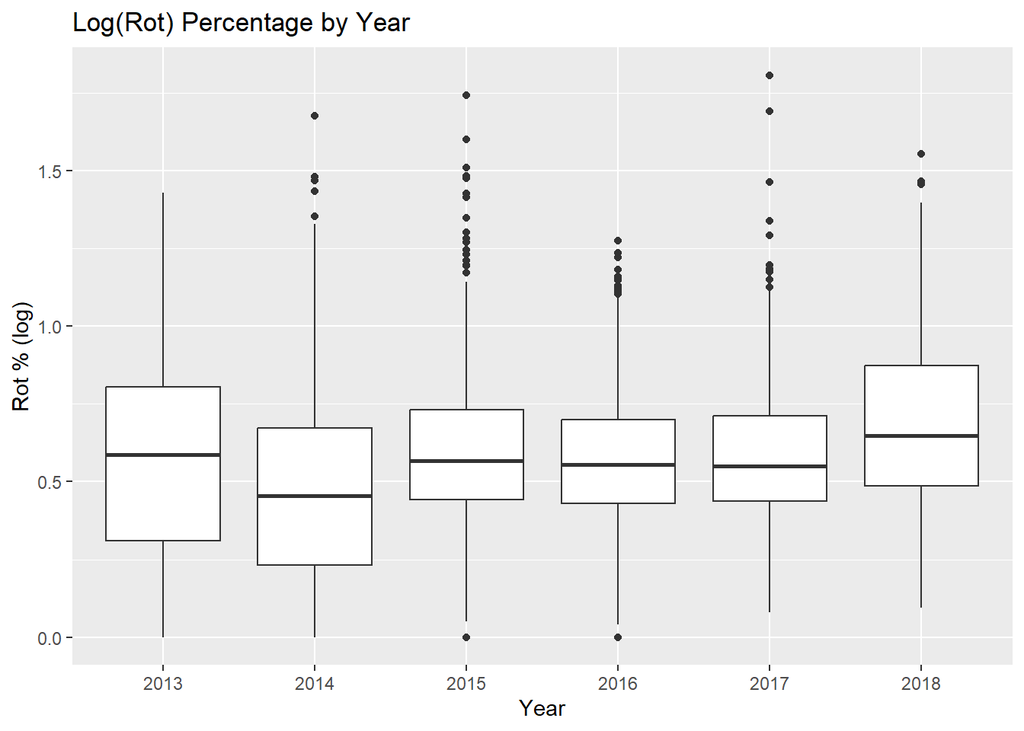

```r
kqf_data_combined %>%
  group_by(year) %>%
  filter(year %in% 2013:2018) %>%
  ggplot(aes(as.factor(year), log_rot)) +
  geom_boxplot() +
  labs(x = "Year",
       y = "Rot % (log)",
       title = "Log(Rot) Percentage by Year") +
  theme_grey()
```

#### 5.2.1.2 by variety

**log(rot) by variety**

- Description: Boxplot of log-transformed rot percentage by cranberry variety
- interpretation: The plot shows apparent differences between different cranberry varieties, with Stevens (ST) having the highest mean rot percentage value and the “other” category having the lowest. Stevens is also the most common variety within the data set.

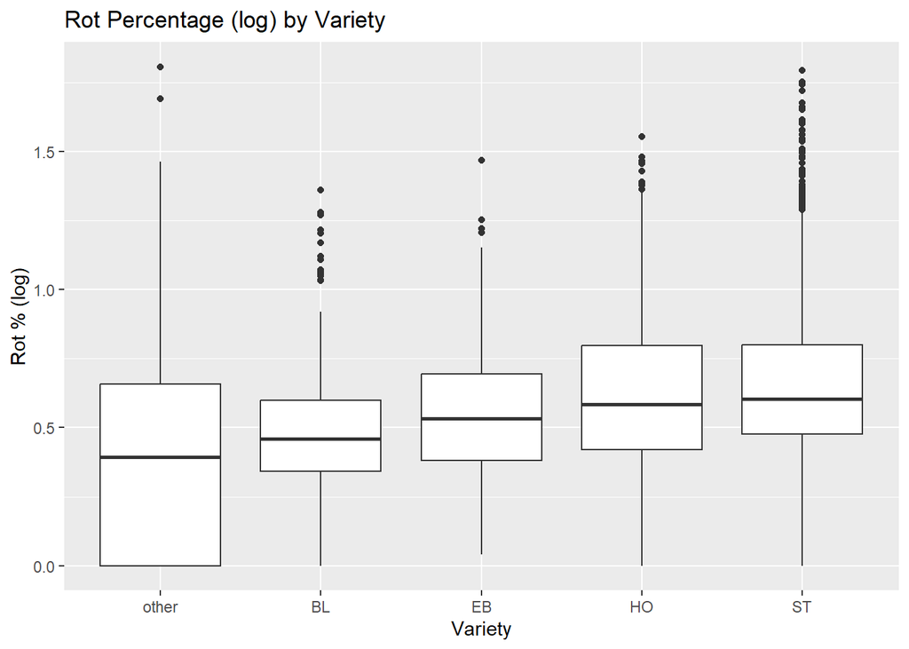

```r
kqf_data_combined$variety <- factor(kqf_data_combined$variety, levels = c("other", "BL", "EB", "HO", "ST"))

kqf_data_combined %>%
  group_by(variety) %>%
  filter(is.na(variety) != T) %>%
  ggplot(aes(as.factor(variety), log_rot)) +
  geom_boxplot() +
  labs(x = "Variety",
       y = "Rot % (log)",
       title = "Rot Percentage (log) by Variety") +
  theme_grey()
```

#### 5.2.1.3 By KQF

**log(rot) by KQF**

- **Description:** Boxplot showing the log-transformed rot percentage versus the final KQF points that were present in the selected year range (2013-18)
- **Interpretation:** In this graphic it appears that there is no clear relationship between final KQF and rot percentage in the selected period.

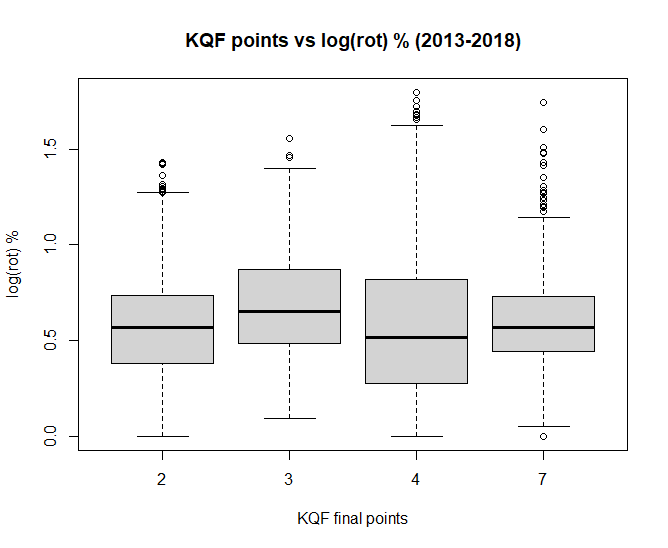

```r
include_graphics(here("report", "kqf_vs_logrot.png"), dpi = 100)
```

### 5.2.2 numerical

**Decas quality parameter summary**

```r
kqf_data_combined %>%
filter(data_source =="decas") %>%
  filter(is.na(rot_pct) == F) %>%
  select(rot_pct,  color, variety) %>%
  summary(.)
```

```
##     rot_pct           color        variety
##  Min.   : 0.000   Min.   : 1.00   other: 749
##  1st Qu.: 1.450   1st Qu.:27.00   BL   : 380
##  Median : 2.600   Median :35.00   EB   : 519
##  Mean   : 3.681   Mean   :35.48   HO   : 620
##  3rd Qu.: 4.400   3rd Qu.:44.00   ST   :1783
##  Max.   :63.310   Max.   :72.00
##                   NA's   :322
```

**CIG quality paramter summary**

```r
kqf_data_combined %>%
  filter(data_source == "cig" | data_source == "cig_lw") %>%
  filter(is.na(rot_pct) == F) %>%
  select(wt_p_berry, rot_pct, tacy, absorbance, variety) %>%
  summary(.)
```

```
##    wt_p_berry        rot_pct             tacy         absorbance      variety
##  Min.   :0.9312   Min.   : 0.7936   Min.   : 9.00   Min.   :0.0800   other: 0
##  1st Qu.:1.5961   1st Qu.: 7.7350   1st Qu.:16.00   1st Qu.:0.1400   BL   : 0
##  Median :1.7576   Median :15.0000   Median :23.00   Median :0.2000   EB   : 0
##  Mean   :1.7610   Mean   :18.3075   Mean   :24.42   Mean   :0.2099   HO   : 0
##  3rd Qu.:1.9199   3rd Qu.:25.0828   3rd Qu.:30.00   3rd Qu.:0.2600   ST   :95
##  Max.   :2.2498   Max.   :61.4657   Max.   :56.00   Max.   :0.4800
```

## 5.3 KQF

### 5.3.1 graphical

**Preliminary KQF vs Final KQF (normalized)**

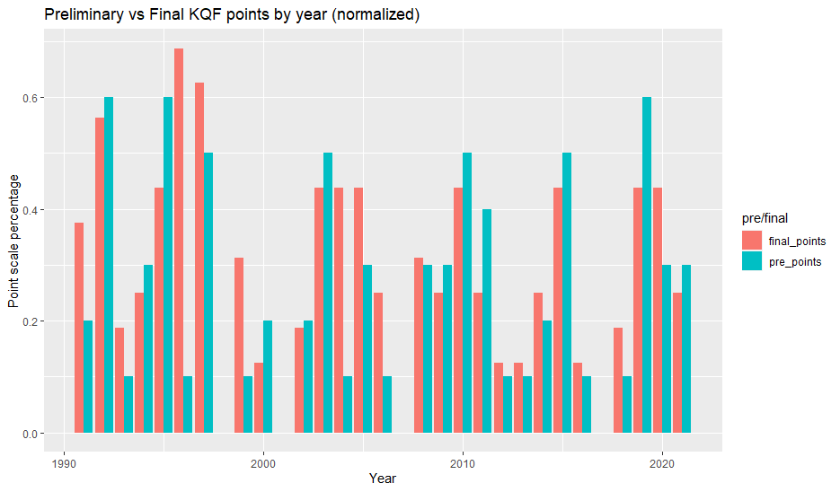

#### 5.3.1.1 KQF correlations

- **Description:** Correlation heat map of KQF values compared to climate values using Spearman correlation method
- **interpretation:** Pre- and final KQF values are closely correlated with each other (as expected). There also appears to be a positive correlation between KQF values and total precipitation as well as a negative correlation between average temperature and KQF.

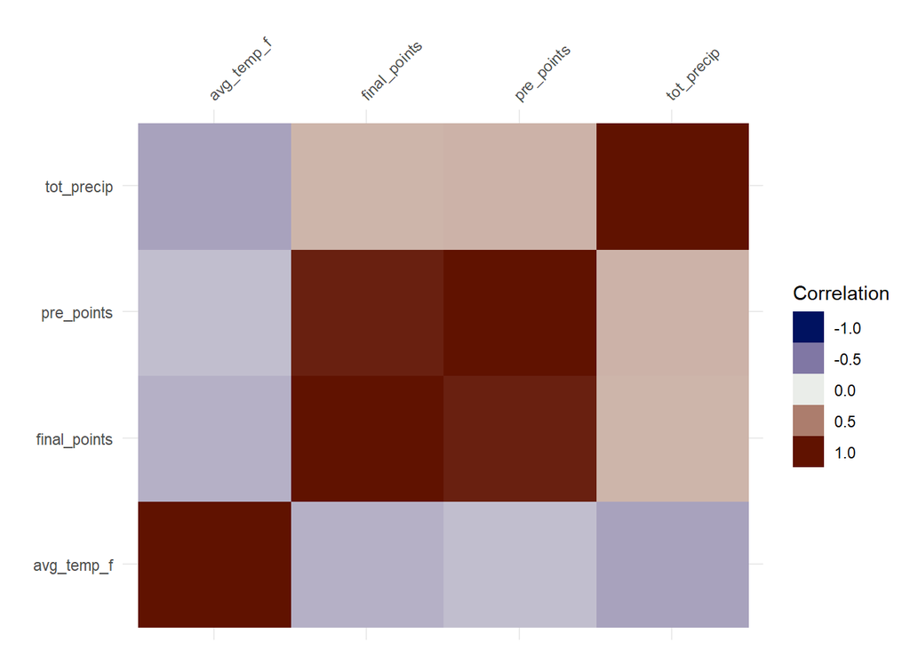

```r
kqf_data_combined %>%
  select(final_points, pre_points,avg_temp_f, tot_precip) %>%
  vis_cor(cor_method = "spearman")
```

- **Description:** Correlation heat map of KQF values compared to quality parameter values using Spearman correlation method
- **Interpretation:** Rot percentage appears to be negatively correlated with total anthocyanin content. There does not appear to be any other apparent correlations in this graphic

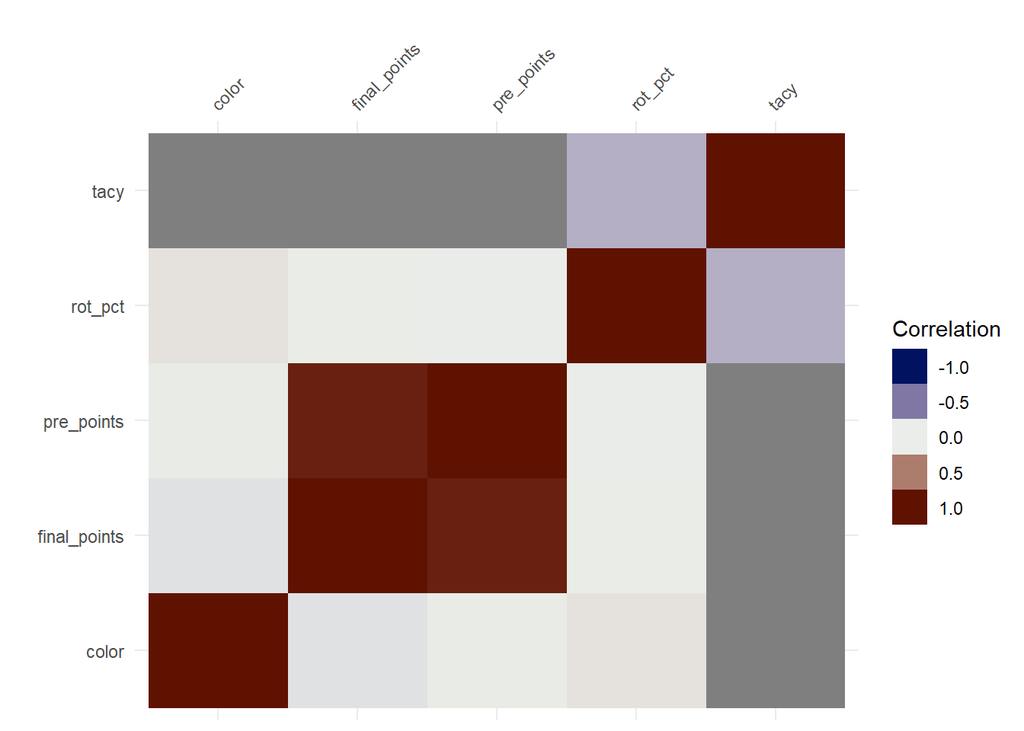

```r
kqf_data_combined %>%
  select(final_points, pre_points,rot_pct, tacy, color) %>%
  vis_cor(cor_method = "spearman")
```

```r
summary(kqf_data_combined)
```

```
##       site         rep          wt_p_berry       rot_pct
##  1      :    5   1   :   19   Min.   :0.931   Min.   : 0.000
##  2      :    5   2   :   19   1st Qu.:1.596   1st Qu.: 1.480
##  3      :    5   3   :   19   Median :1.758   Median : 2.645
##  4      :    5   4   :   19   Mean   :1.761   Mean   : 4.016
##  5      :    5   5   :   19   3rd Qu.:1.920   3rd Qu.: 4.598
##  (Other):   70   NA's:20897   Max.   :2.250   Max.   :63.310
##  NA's   :20897                NA's   :20897   NA's   :16846
##  yield_acre_barrel yield_ha_barrel  yield_ac_kg     yield_ac_lb
##  Min.   : 58.96    Min.   : 6606   Min.   : 2675   Min.   : 5896
##  1st Qu.:166.76    1st Qu.:18683   1st Qu.: 7564   1st Qu.:16676
##  Median :199.09    Median :22305   Median : 9030   Median :19909
##  Mean   :208.65    Mean   :23376   Mean   : 9464   Mean   :20865
##  3rd Qu.:251.46    3rd Qu.:28173   3rd Qu.:11406   3rd Qu.:25146
##  Max.   :387.73    Max.   :43440   Max.   :17587   Max.   :38772
##  NA's   :20897     NA's   :20897   NA's   :20897   NA's   :20897
##       tacy         absorbance       log_rot       variety           year
##  Min.   : 9.00   Min.   :0.08    Min.   :0.000   other:  749   Min.   :1991
##  1st Qu.:16.00   1st Qu.:0.14    1st Qu.:0.394   BL   :  380   1st Qu.:2012
##  Median :23.00   Median :0.20    Median :0.562   EB   :  519   Median :2014
##  Mean   :24.42   Mean   :0.21    Mean   :0.576   HO   :  620   Mean   :2014
##  3rd Qu.:30.00   3rd Qu.:0.26    3rd Qu.:0.748   ST   : 1878   3rd Qu.:2016
##  Max.   :56.00   Max.   :0.48    Max.   :1.808   NA's :16846   Max.   :2022
##  NA's   :20897   NA's   :20897   NA's   :16846
##      month        data_source        date
##  Min.   : 1.000   cig  :  169   Min.   :2011-04-30 00:00:00.00
##  1st Qu.: 6.000   decas:20576   1st Qu.:2012-07-18 00:00:00.00
##  Median : 7.000   NA's :  247   Median :2014-07-12 00:00:00.00
##  Mean   : 7.255                 Mean   :2014-09-22 06:52:15.92
##  3rd Qu.: 7.000                 3rd Qu.:2016-07-11 00:00:00.00
##  Max.   :12.000                 Max.   :2021-07-18 00:00:00.00
##  NA's   :12                     NA's   :342
##     grower              bog                debris          color
##  Length:20992       Length:20992       Min.   :0.000   Min.   : 1.00
##  Class :character   Class :character   1st Qu.:0.000   1st Qu.:27.00
##  Mode  :character   Mode  :character   Median :0.000   Median :35.00
##                                        Mean   :0.003   Mean   :35.48
##                                        3rd Qu.:0.000   3rd Qu.:44.00
##                                        Max.   :3.000   Max.   :72.00
##                                        NA's   :17194   NA's   :17263
##    avg_temp_f      tot_precip                  treatment
##  Min.   :19.60   Min.   : 0.500   Bravo Ultrex      :3780
##  1st Qu.:64.10   1st Qu.: 2.640   Bravo Weather Stik:3260
##  Median :66.50   Median : 3.360   Abound            :3076
##  Mean   :65.99   Mean   : 4.052   Indar 2F          :3030
##  3rd Qu.:73.00   3rd Qu.: 5.050   Chloronil 720     : 764
##  Max.   :78.00   Max.   :13.520   (Other)           :2689
##  NA's   :24      NA's   :24       NA's              :4393
##             ingredient     pre_points     final_points
##  Chlorothalonil  :8687   Min.   :0.000   Min.   : 0.000
##  Azoxystrobin    :3153   1st Qu.:1.000   1st Qu.: 2.000
##  Fenbuconazole   :3072   Median :1.000   Median : 2.000
##  EBDC            : 723   Mean   :2.254   Mean   : 3.313
##  Copper Hydroxide: 711   3rd Qu.:4.000   3rd Qu.: 4.000
##  (Other)         : 253   Max.   :6.000   Max.   :11.000
##  NA's            :4393   NA's   :24      NA's   :2045
```

### 5.3.2 numeric

```r
# # Avg_temp F ~ tot_precip
# cor(kqf_data_combined$avg_temp_f, kqf_data_combined$tot_precip,
#     method = "spearman",
#     use = "pairwise.complete.obs")
```

# 6 **Further considerations**

### 6.0.1 **Questions that arose in the process:**

- Is there a relationship between fungicide application counts and KQF values by year?
- What is the correlation between number/type of fungicide applications and mean rot %? and Kqf value?
- Which KQF factor is a better single predictor of quality; total precipitation, sunshine hours, or average temperature?
- Is final KQF the most effective for prediction? What is the relative predictive strength/weakness of the preliminary KQF compared to final?

### 6.0.2 **Next steps:**

- Integrate additional data points into the combined set (as appropriate)
- Fully define investigative hypotheses
- Perform more comprehensive data analysis to test hypotheses
- Construct publication-quality graphics and tables